[figure not shown]

BC(diag)-28

Diagnostic Procedure with Diagnostic Trouble Code (DTC)

BODY CONTROL SYSTEM (DIAGNOSTICS)

14.Diagnostic Procedure with Diagnostic Trouble Code (DTC)

A: DTC B1010 INTEG. UNIT SYSTEM ERROR

DTC DETECTING CONDITION:

System error in body integrated unit

TROUBLE SYMPTOM:

LAN communication immobilizer function may not be executed normally.

Step Check Yes No

1 CHECK DTC.

Check DTC indicated by body integrated unit.

Is B1010 current malfunction? Go to step 2. Temporary

EEPROM access

error occurred.

2 CHECK CONNECTOR.

1) Turn the ignition switch to OFF.

2) Disconnect the body integrated unit connec-

tor.

3) Connect the disconnected connectors.

4) Read the DTC of body integrated unit using

Subaru Select Monitor.

Is B1010 current malfunction? Replace the body

integrated unit.

<Ref. to SL-78,

REMOVAL, Body

Integrated Unit.>

Temporar y

EEPROM access

error occurred.

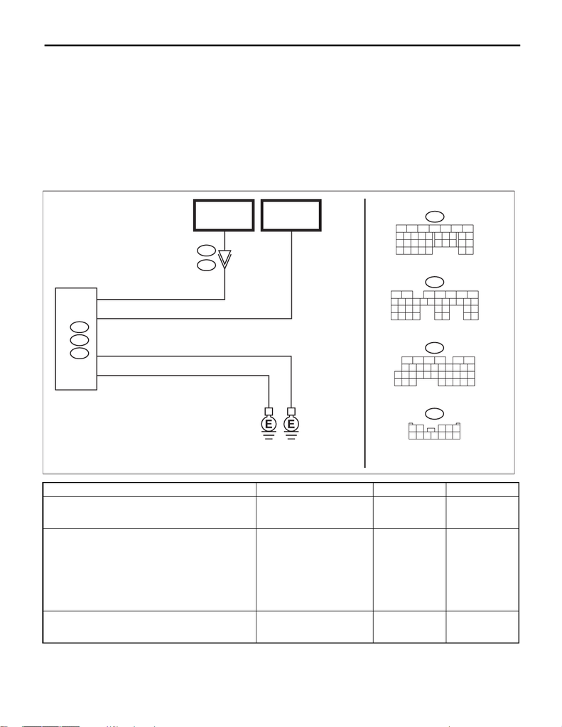

BC(diag)-29

Diagnostic Procedure with Diagnostic Trouble Code (DTC)

BODY CONTROL SYSTEM (DIAGNOSTICS)

B: DTC B1011 BATT P/SUPPLY MALFUNCTION CONT

DTC DETECTING CONDITION:

• Voltage failure caused by poor contact of battery power supply control circuit

• Battery voltage of body integrated unit is not within the 8.5 — 16.5 V range.

TROUBLE SYMPTOM:

Functions of body integrated unit stop.

NOTE:

When B1012 BATT P/SUPPLY MALFUNCTION BACKUP is output at the same time, all the function of body

integrated unit may not operate.

WIRING DIAGRAM:

Immobilizer system <Ref. to WI-259, WIRING DIAGRAM, Immobilizer System.>

Step Check Yes No

1 CHECK DTC.

Read the DTC of body integrated unit using

Subaru Select Monitor.

Is B1011 current malfunction? Go to step 2. Go to step 5.

2 CHECK DTC.

1) Turn the ignition switch to OFF.

2) Disconnect and then connect the body inte-

grated unit connector.

3) Wait approx. 2 minutes.

4) Turn the ignition switch to ON.

5) Read the DTC of body integrated unit using

Subaru Select Monitor.

Is B1011 current malfunction? Go to step 3. Go to step 5.

3 CHECK FUSE.

1) Turn the ignition switch to OFF.

2) Check the fuse.

Is the fuse OK? Go to step 4. Replace the defec-

tive fuse.

i229

12 345

6789

10 11 12

B280

A:

18

23

26

24

25

98

15

1413121110

17

16

7123456

i84

C:

19

18

21

20 23

22 24 25 26

17

1

234

65

27

28 29 30

31 32 33 34 35

798

151413121110 16

3

i229

B551

B280

A:

B281

B:

i84

C:

A1

C1

B281

B:

19

18

21

20

23

22 24 25

26

17

21

73456

27

28 29 30 31

32 33

34 35

98

151413121110 16

C6

B7

LAN01437

BODY INTEGRATED UNIT

MB-29

M/B FUSE NO. 8

(B)

FB-18

F/B FUSE NO. 7

(B)

[figure not shown]

BC(diag)-30

Diagnostic Procedure with Diagnostic Trouble Code (DTC)

BODY CONTROL SYSTEM (DIAGNOSTICS)

4 CHECK HARNESS.

1) Disconnect the body integrated unit connec-

tor.

2) Using the tester, measure the voltage

between terminals.

Connector & terminal

(i84) No. 6 (+) — Chassis ground (–):

Is the voltage 8.5 — 16.5 V? Replace the body

integrated unit.

<Ref. to SL-78,

REMOVAL, Body

Integrated Unit.>

Repair the harness

between body inte-

grated unit and

fuse.

5 CHECK CONNECTOR.

1) Turn the ignition switch to OFF.

2) Disconnect the body integrated unit connec-

tor.

Is there poor contact of connec-

tor?

Repair or replace

the poor contact of

connector.

A temporary

change of voltage

occurred.

Step Check Yes No

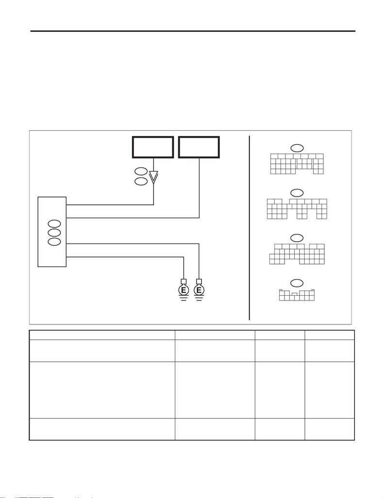

BC(diag)-31

Diagnostic Procedure with Diagnostic Trouble Code (DTC)

BODY CONTROL SYSTEM (DIAGNOSTICS)

C: DTC B1012 BATT P/SUPPLY MALFUNCTION BACKUP

DTC DETECTING CONDITION:

Voltage failure caused by poor contact of battery power supply backup circuits

TROUBLE SYMPTOM:

Illuminations for the keyless entry, map light, luggage light, trunk light, room light, and ignition switch do not

turn on.

NOTE:

When B1011 BATT P/SUPPLY MALFUNCTION CONT. is output at the same time, all function of body inte-

grated unit may not operate.

WIRING DIAGRAM:

Immobilizer system <Ref. to WI-259, WIRING DIAGRAM, Immobilizer System.>

Step Check Yes No

1 CHECK DTC.

Read the DTC of body integrated unit using

Subaru Select Monitor.

Is B1012 current malfunction? Go to step 2. Go to step 5.

2 CHECK DTC.

1) Turn the ignition switch to OFF.

2) Disconnect and then connect the body inte-

grated unit connector.

3) Wait approx. 2 minutes.

4) Turn the ignition switch to ON.

5) Read the DTC of body integrated unit using

Subaru Select Monitor.

Is B1012 current malfunction? Go to step 3. Go to step 5.

3 CHECK FUSE.

1) Turn the ignition switch to OFF.

2) Check the fuse.

Is the fuse OK? Go to step 4. Replace the defec-

tive fuse.

i229

12 345

6789

10 11 12

B280

A:

18

23

26

24

25

98

15

1413121110

17

16

7123456

i84

C:

19

18

21

20 23

22 24 25 26

17

1

234

65

27

28 29 30

31 32 33 34 35

798

151413121110 16

3

i229

B551

B280

A:

B281

B:

i84

C:

A1

C1

B281

B:

19

18

21

20

23

22 24 25

26

17

21

73456

27

28 29 30 31

32 33

34 35

98

151413121110 16

C6

B7

LAN01437

BODY INTEGRATED UNIT

MB-29

M/B FUSE NO. 8

(B)

FB-18

F/B FUSE NO. 7

(B)

[figure not shown]

BC(diag)-32

Diagnostic Procedure with Diagnostic Trouble Code (DTC)

BODY CONTROL SYSTEM (DIAGNOSTICS)

4 CHECK HARNESS.

1) Disconnect the body integrated unit connec-

tor.

2) Using the tester, measure the voltage

between terminals.

Connector & terminal

(B281) No. 7 (+) — Chassis ground (–):

Is the voltage 8.5 — 16.5 V? Replace the body

integrated unit.

<Ref. to SL-78,

REMOVAL, Body

Integrated Unit.>

Repair the harness

between body inte-

grated unit and

fuse.

5 CHECK CONNECTOR.

1) Turn the ignition switch to OFF.

2) Disconnect the body integrated unit connec-

tor.

Is there poor contact of connec-

tor?

Repair or replace

the poor contact of

connector.

A temporary

change of voltage

occurred.

Step Check Yes No

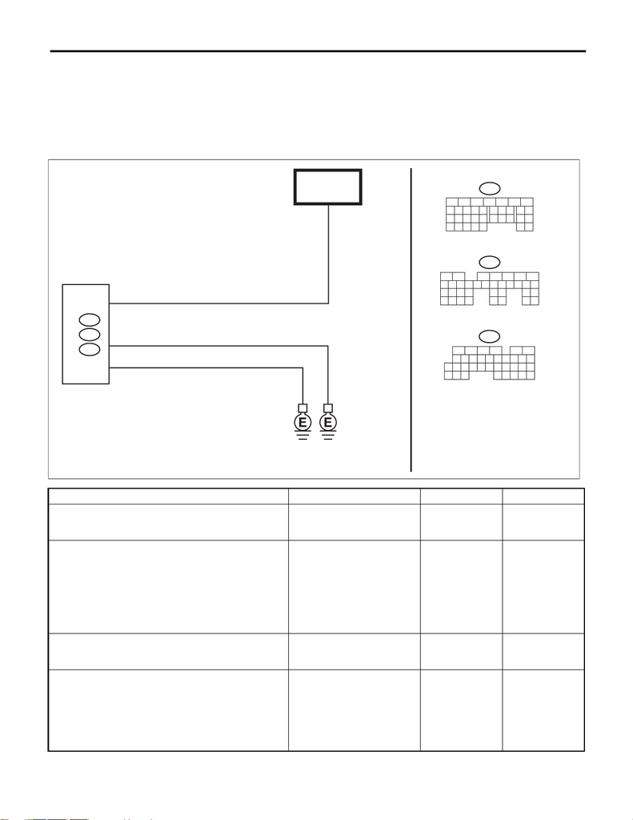

BC(diag)-33

Diagnostic Procedure with Diagnostic Trouble Code (DTC)

BODY CONTROL SYSTEM (DIAGNOSTICS)

D: DTC B1013 IGNITION POWER FAILURE

DTC DETECTING CONDITION:

Voltage failure caused by poor contact of IGN power supply circuits

TROUBLE SYMPTOM:

Symptoms such as shift lock or wiper not operating may occur.

WIRING DIAGRAM:

Shift lock control system <Ref. to WI-384, WIRING DIAGRAM, Shift Lock Control System.>

Step Check Yes No

1 CHECK DTC.

Read the DTC of body integrated unit using

Subaru Select Monitor.

Is B1013 current malfunction? Go to step 2. Go to step 5.

2 CHECK DTC.

1) Turn the ignition switch to OFF.

2) Disconnect and then connect the body inte-

grated unit connector.

3) Wait approx. 2 minutes.

4) Turn the ignition switch to ON.

5) Read the DTC of body integrated unit using

Subaru Select Monitor.

Is B1013 current malfunction? Go to step 3. Go to step 5.

3 CHECK FUSE.

1) Turn the ignition switch to OFF.

2) Check the fuse.

Is the fuse OK? Go to step 4. Replace the defec-

tive fuse.

4 CHECK HARNESS.

1) Disconnect the body integrated unit connec-

tor.

2) Using the tester, measure the voltage

between terminals.

Connector & terminal

(B281) No. 3 (+) — Chassis ground (–):

Is the voltage 8.5 — 16.5 V? Replace the body

integrated unit.

<Ref. to SL-78,

REMOVAL, Body

Integrated Unit.>

Repair the harness

between body inte-

grated unit and

fuse.

B280

A:

18

23

26

24

25

98

15

1413121110

17

16

7123456

i84

C:

19

18

21

20 23

22 24 25 26

17

1

234

65

27

28 29 30

31 32 33 34 35

798

151413121110 16

B280

A:

B281

B:

i84

C:

A1

C1

B281

B:

19

18

21

20

23

22 24 25

26

17

21

73456

27

28 29 30 31

32 33

34 35

98

151413121110 16

B3

LAN01438

BODY INTEGRATED UNIT

FB-38

F/B FUSE NO. 12

(IG)

[figure not shown]

BC(diag)-34

Diagnostic Procedure with Diagnostic Trouble Code (DTC)

BODY CONTROL SYSTEM (DIAGNOSTICS)

5 CHECK CONNECTOR.

1) Turn the ignition switch to OFF.

2) Disconnect the body integrated unit connec-

tor.

Is there poor contact of connec-

tor?

Repair or replace

the poor contact of

connector.

A temporary

change of voltage

occurred.

Step Check Yes No

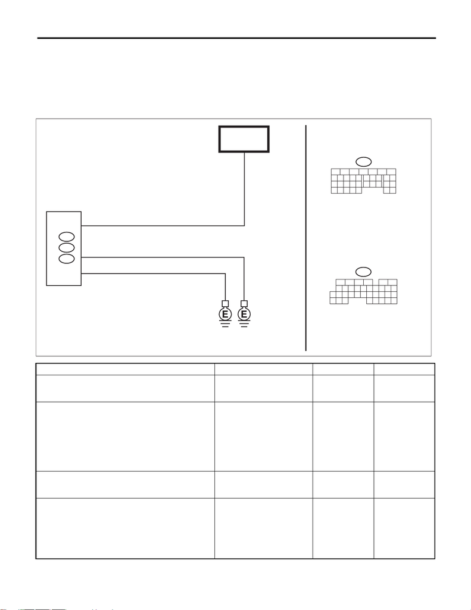

BC(diag)-35

Diagnostic Procedure with Diagnostic Trouble Code (DTC)

BODY CONTROL SYSTEM (DIAGNOSTICS)

E: DTC B1014 ACC POWER FAILURE

DTC DETECTING CONDITION:

Voltage failure caused by poor contact of ACC power supply circuit

TROUBLE SYMPTOM:

DRL may not illuminate.

WIRING DIAGRAM:

Shift lock control system <Ref. to WI-384, WIRING DIAGRAM, Shift Lock Control System.>

Step Check Yes No

1 CHECK DTC.

Read the DTC of body integrated unit using

Subaru Select Monitor.

Is B1014 current malfunction? Go to step 2. Go to step 5.

2 CHECK DTC.

1) Turn the ignition switch to OFF.

2) Disconnect and then connect the body inte-

grated unit connector.

3) Wait approx. 2 minutes.

4) Turn the ignition switch to ON.

5) Read the DTC of body integrated unit using

Subaru Select Monitor.

Is B1014 current malfunction? Go to step 3. Go to step 5.

3 CHECK FUSE.

1) Turn the ignition switch to OFF.

2) Check the fuse.

Is the fuse OK? Go to step 4. Replace the defec-

tive fuse.

4 CHECK HARNESS.

1) Disconnect the body integrated unit connec-

tor.

2) Using the tester, measure the voltage

between terminals.

Connector & terminal

(B280) No. 32 (+) — Chassis ground (–):

Is the voltage 8.5 — 16.5 V? Replace the body

integrated unit.

<Ref. to SL-78,

REMOVAL, Body

Integrated Unit.>

Repair the harness

between body inte-

grated unit and

fuse.

B280

A:

18

23

26

24

25

98

15

1413121110

17

16

7123456

i84

C:

19

18

21

20 23

22 24 25 26

17

1

234

65

27

28 29 30

31 32 33 34 35

798

151413121110 16

B280

A:

B281

B:

i84

C:

A1

C1

A32

LAN01439

BODY INTEGRATED UNIT

FB-29

F/B FUSE NO. 31

(ACC)

[figure not shown]

BC(diag)-36

Diagnostic Procedure with Diagnostic Trouble Code (DTC)

BODY CONTROL SYSTEM (DIAGNOSTICS)

5 CHECK CONNECTOR.

1) Turn the ignition switch to OFF.

2) Disconnect the body integrated unit connec-

tor.

Is there poor contact of connec-

tor?

Repair or replace

the poor contact of

connector.

A temporary

change of voltage

occurred.

Step Check Yes No

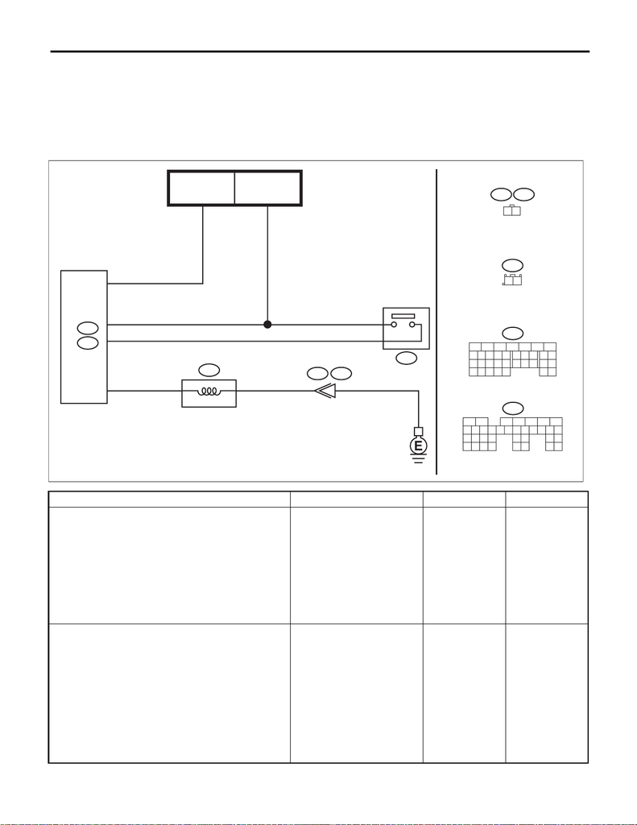

BC(diag)-37

Diagnostic Procedure with Diagnostic Trouble Code (DTC)

BODY CONTROL SYSTEM (DIAGNOSTICS)

F: DTC B1015 KEY INTERLOCK CIRCUIT ABNORMAL

DTC DETECTING CONDITION:

Short to ground in key interlock circuit

TROUBLE SYMPTOM:

Key interlock does not keep lock condition.

WIRING DIAGRAM:

Shift lock control system <Ref. to WI-384, WIRING DIAGRAM, Shift Lock Control System.>

Step Check Yes No

1 CHECK DTC.

1) Insert the ignition key.

2) Turn the ignition switch to ON.

3) Shift to the Neutral range.

4) Shift into P range.

5) Shift to the Neutral range.

6) Shift into P range.

7) Shift to the Neutral range.

8) Read the DTC of body integrated unit using

Subaru Select Monitor.

Is B1015 current malfunction? Go to step 2. Go to step 8.

2 CHECK DTC.

1) Shift the select lever to P range.

2) Remove the ignition key.

3) Disconnect the key actuator connector

(B557) and body integrated unit connector

(B281).

4) Connect the disconnected connectors.

5) Insert the ignition key.

6) Turn the ignition switch to ON and shift into

Neutral.

7) Read the DTC of body integrated unit using

Subaru Select Monitor.

Is B1015 current malfunction? Go to step 3. Go to step 8.

1

B123 B124

21

B557

B555

2

1

B123

12

B:

B281

19

18

21

20

23

22 24 25

26

17

21

73456

27

28 29 30 31

32 33

34 35

98

151413121110 16

A:

B280

18

23

26

24

25

98

15

1413121110

17

16

7123456

B555 B557

12

B280

A:

B281

B:

B4

A4

B3

B6

LAN01440

BODY INTEGRATED UNIT

MB-28

M/B FUSE NO. 14

(B)

FB-38

F/B FUSE NO. 12

(IG)

KEY WARNING SWITCH

KEY LOCK SOLENOID

KEY LOCK

[figure not shown]

BC(diag)-38

Diagnostic Procedure with Diagnostic Trouble Code (DTC)

BODY CONTROL SYSTEM (DIAGNOSTICS)

3 CHECK KEY ACTUATOR.

1) Turn the ignition switch to OFF.

2) Disconnect the key actuator connector

(B557).

3) Measure the resistance between key actua-

tor connectors.

Connector & terminal

(B557) No. 1 — No. 2:

Is the resistance 103 — 115 Ω? Go to step 4. Replace the key

actuator.

4 CHECK KEY ACTUATOR.

Connect the battery terminals to the key actua-

tor.

Terminals

(B557) No. 1 — positive terminal:

(B557) No. 2 — ground terminal:

Is the actuator activated and

then key locked?

Go to step 5. Replace the key

actuator.

5 CHECK HARNESS.

1) Disconnect the body integrated unit connec-

tor (B281).

2) Measure the resistance between body inte-

grated unit and key actuator using tester.

Connector & terminal

(B557) No. 1 — (B281) No. 4:

Is the resistance less than 10

Ω?

Go to step 6. Repair or replace

the open circuit of

harness.

6 CHECK HARNESS.

Measure the resistance between body inte-

grated unit and chassis ground using tester.

Connector & terminal

(B281) No. 4 — Chassis ground:

Is the resistance 1 MΩ or

more?

Go to step 7. Repair or replace

the short circuit of

the harness.

7 CHECK HARNESS.

1) Connect the body integrated unit.

2) Turn the ignition switch to ON.

3) Measure the voltage between body inte-

grated unit and chassis ground using tester.

Connector & terminal

(B281) No. 4 (+) — Chassis ground (–):

Is the voltage 6 V or more? Go to step 8. Replace the body

integrated unit.

<Ref. to SL-78,

REMOVAL, Body

Integrated Unit.>

8 CHECK CONNECTOR.

1) Turn the ignition switch to OFF.

2) Disconnect the body integrated unit connec-

tor (B281) and key actuator connector (B557).

Is there poor contact at discon-

nected connector terminal?

Repair the terminal

where poor contact

exists, or replace

harness.

It is possible that

temporary poor

contact occurs.

Step Check Yes No

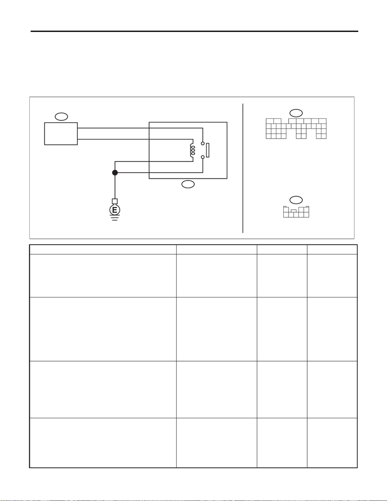

BC(diag)-39

Diagnostic Procedure with Diagnostic Trouble Code (DTC)

BODY CONTROL SYSTEM (DIAGNOSTICS)

G: DTC B1016 SHIFT LOCK CIRCUIT FAILURE

DTC DETECTING CONDITION:

Shift lock circuit is open, or shorted to power or ground.

TROUBLE SYMPTOM:

Shift lock does not be released or remain locked.

WIRING DIAGRAM:

Shift lock control system <Ref. to WI-384, WIRING DIAGRAM, Shift Lock Control System.>

Step Check Yes No

1 CHECK DTC.

1) Turn the ignition switch to ON.

2) Keep the Parking range for approx. 5 sec-

onds.

3) Read the DTC of body integrated unit using

Subaru Select Monitor.

Is B1016 current malfunction? Go to step 6. Go to step 2.

2 CHECK DTC.

1) Turn the ignition switch to OFF.

2) Disconnect the shift lock solenoid connec-

tor.

3) Connect the disconnected connectors.

4) Turn the ignition switch to ON, then keep the

Parking range for approx. 5 seconds.

5) Read the DTC of body integrated unit using

Subaru Select Monitor.

Is B1016 current malfunction? Go to step 3. Go to step 7.

3 CHECK HARNESS.

1) Turn the ignition switch to OFF.

2) Disconnect the shift lock solenoid connec-

tor.

3) Using the tester, measure the resistance

between terminals.

Connector & terminal

(B116) No. 4 — Chassis ground:

Is the resistance less than 10

Ω?

Go to step 4. Repair or replace

the open circuit of

harness.

4 CHECK SHIFT LOCK SOLENOID.

Using a tester, measure the resistance between

shift lock solenoid terminals.

Connector & terminal

(B116) No. 4 — No. 3:

Is the resistance less than 27 —

31 Ω?

Go to step 5. Replace the shift

lock solenoid.

<Ref. to CS-50,

REMOVAL, AT

Shift Lock Solenoid

and “P” Range

Switch.>

B116

19

18

21

20

23

22 24 25

26

17

12

34567

27

28 29 30 31

32 33

34 35

98

151413121110 16

B281

B

B

B281

2

1

4

3

B116

7856

3

4

1

2

B5

B18

LAN01441

:

:

BODY INTEGRATED UNIT

SELECT LEVER

SHIFT LOCK

SOLENOID

[figure not shown]

BC(diag)-40

Diagnostic Procedure with Diagnostic Trouble Code (DTC)

BODY CONTROL SYSTEM (DIAGNOSTICS)

5 CHECK SHIFT LOCK SOLENOID.

Connect the battery terminal to shift lock sole-

noid.

Connector & terminal

(B116) No. 3 — positive terminal:

(B116) No. 4 — ground terminal:

Does the shift lock solenoid

operate and then release the

lock?

Go to step 6. Replace the shift

lock solenoid.

<Ref. to CS-50,

REMOVAL, AT

Shift Lock Solenoid

and “P” Range

Switch.>

6 CHECK HARNESS.

Use a tester to measure the resistance between

harness terminals.

Connector & terminal

(B116) No. 3 — (B281) No. 5:

NOTE:

If body integrated unit and shift lock connector

are not disconnected, disconnect them first and

then perform measurement.

Is the resistance less than 10

Ω?

Replace the body

integrated unit.

<Ref. to SL-78,

Body Integrated

Unit.>

Repair or replace

the open circuit of

harness.

7 CHECK DTC.

1) Depress the brake pedal at the parking

range.

2) Read the DTC of body integrated unit using

Subaru Select Monitor.

Is B1016 current malfunction? Go to step 8. Go to step 9.

8 CHECK DTC.

1) Turn the ignition switch to OFF.

2) Disconnect the body integrated unit connec-

tor and shift lock connector.

3) Connect the disconnected connectors.

4) Turn the ignition switch to ON.

5) Depress the brake pedal at the parking

range.

6) Read the DTC of body integrated unit using

Subaru Select Monitor.

Is B1016 current malfunction? Go to step 4. Go to step 9.

9 CHECK CONNECTOR.

1) Turn the ignition switch to OFF.

2) Disconnect the body integrated unit connec-

tor and shift lock connector.

Is there poor contact of connec-

tor terminal?

Repair or replace

the poor contact of

terminal.

It is possible that

temporary poor

contact occurs.

Step Check Yes No

[figure not shown]

BC(diag)-41

Diagnostic Procedure with Diagnostic Trouble Code (DTC)

BODY CONTROL SYSTEM (DIAGNOSTICS)

H: DTC B1401 M COLLATION NG

For detailed diagnosis procedure, refer to IMMOBILIZER (DIAG). <Ref. to IM(diag)-24, DTC B1401 M COL-

LATION NG, Diagnostic Procedure with Diagnostic Trouble Code (DTC).>

I: DTC B1402 IMMOBILIZER KEY COLLATION NG

For detailed diagnosis procedure, refer to IMMOBILIZER (DIAG). <Ref. to IM(diag)-24, DTC B1402 IMMO-

BILIZER KEY COLLATION NG, Diagnostic Procedure with Diagnostic Trouble Code (DTC).>

J: DTC B1405 SCU COLLATION NG

For detailed diagnosis procedure, refer to IMMOBILIZER (DIAG). <Ref. to IM(diag)-25, DTC B1405 SCU

COLLATION NG, Diagnostic Procedure with Diagnostic Trouble Code (DTC).>

K: DTC B1406 SCU_EEPROM_NG

For detailed diagnosis procedure, refer to IMMOBILIZER (DIAG). <Ref. to IM(diag)-25, DTC B1406

SCU_EEPROM_NG, Diagnostic Procedure with Diagnostic Trouble Code (DTC).>

L: DTC B1407 M COMMUNICATION ABNORMAL

For detailed diagnosis procedure, refer to IMMOBILIZER (DIAGNOSTICS). <Ref. to IM(diag)-26, DTC

B1407 M COMMUNICATION ABNORMAL, Diagnostic Procedure with Diagnostic Trouble Code (DTC).>

M: DTC B1408 METER EEPROM ABNORMAL

For detailed diagnosis procedure, refer to IMMOBILIZER (DIAGNOSTICS). <Ref. to IM(diag)-26, DTC

B1408 METER EEPROM ABNORMAL, Diagnostic Procedure with Diagnostic Trouble Code (DTC).>

N: DTC B1409 SCU COMMUNICATION ABNORMAL

For detailed diagnosis procedure, refer to IMMOBILIZER (DIAGNOSTICS). <Ref. to IM(diag)-27, DTC

B1409 SCU COMMUNICATION ABNORMAL, Diagnostic Procedure with Diagnostic Trouble Code (DTC).>

O: DTC B1410 TRANSPONDER COMMUNICATION ABNORMAL

For detailed diagnosis procedure, refer to IMMOBILIZER (DIAGNOSTICS). <Ref. to IM(diag)-29, DTC

B1410 TRANSPONDER COMMUNICATION ABNORMAL, Diagnostic Procedure with Diagnostic Trouble

Code (DTC).>

P: DTC B1411 IMMOBILIZER ANTENNA ABNORMAL

For detailed diagnosis procedure, refer to IMMOBILIZER (DIAGNOSTICS). <Ref. to IM(diag)-29, DTC

B1411 IMMOBILIZER ANTENNA ABNORMAL, Diagnostic Procedure with Diagnostic Trouble Code

(DTC).>

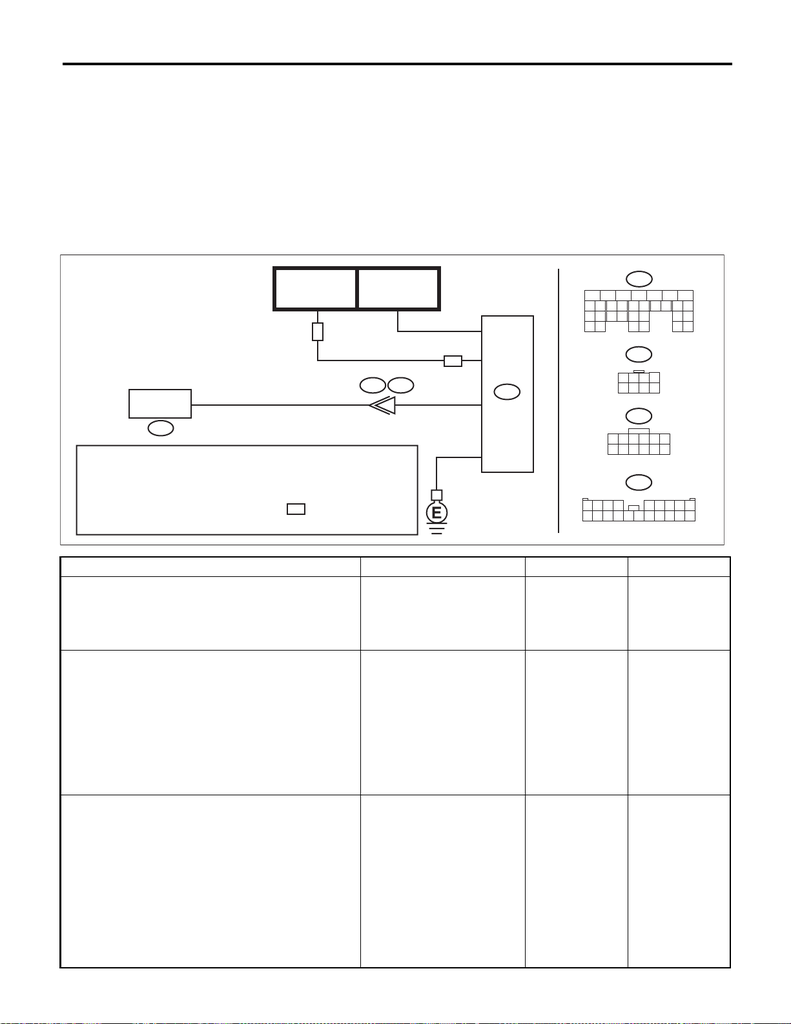

BC(diag)-42

Diagnostic Procedure with Diagnostic Trouble Code (DTC)

BODY CONTROL SYSTEM (DIAGNOSTICS)

Q: DTC U1500 KEYLESS UART COM. MALFUNCTION

1. MODELS WITHOUT KEYLESS ACCESS

DTC DETECTING CONDITION:

UART between the TPMS & keyless entry CM or keyless entry CM and body integrated unit is open or short-

ed, or has communication failure.

TROUBLE SYMPTOM:

• Door lock does not operate with keyless.

• TPMS does not operate. (The indicator blinks.)

WIRING DIAGRAM:

Keyless entry system <Ref. to WI-295, WIRING DIAGRAM, Keyless Entry System.>

Step Check Yes No

1 CHECK DTC.

1) Insert the ignition key to the ignition key cyl-

inder and remove.

2) Read the DTC of body integrated unit using

Subaru Select Monitor.

Is U1500 a current malfunc-

tion?

Go to step 2. Go to step 7.

2 CHECK DTC.

1) Turn the ignition switch to OFF.

2) Disconnect the connectors from the body

integrated unit and the TPMS & keyless entry

CM or the keyless entry CM.

3) Connect the disconnected connectors.

4) Insert the ignition key to the ignition key cyl-

inder and remove.

5) Read the DTC of body integrated unit using

Subaru Select Monitor.

Is U1500 a current malfunc-

tion?

Go to step 3. Go to step 7.

3 CHECK HARNESS.

1) Turn the ignition switch to OFF.

2) Disconnect the connectors from the body

integrated unit and the TPMS & keyless entry

CM or the keyless entry CM.

3) Using the tester, measure the resistance

between terminals.

Connector & terminal

With TPMS

(i171) No. 11 — (R221) No. 11:

Without TPMS

(i171) No. 11 — (R80) No. 3:

Is the resistance 10 Ω or less? Go to step 4. Repair the open

circuit of harness

or replace har-

ness.

TP

TP

TP

4

i102

1234 56789

10 11 12 13 14 15 16 17 18 19 20

R221

11 12

9

10

78

2

4

5

3

2

1

1

i171

19

18

20 21

22

23

26

24

25

27

28 29

30 31

98

15

1413121110

17

16

7123456

D:

D:

i102

R167

i171

D11

R80

213

4

56

78

LAN01604

2

1

3

4

5

BODY INTEGRATED UNIT

FB-11

F/B FUSE NO. 15

(B)

FB-31

F/B FUSE NO. 4

(IG)

: WITHOUT TPMS : 3

WITH TPMS : 11

: WITH TPMS

: WITHOUT TPMS : R80

WITH TPMS : R221

: WITHOUT TPMS : KEYLESS ENTRY CM

WITH TPMS : TPMS & KEYLESS ENTRY CM

: WITHOUT TPMS : 4

WITH TPMS : 6

: WITHOUT TPMS : 7

WITH TPMS : 5

[figure not shown]

BC(diag)-43

Diagnostic Procedure with Diagnostic Trouble Code (DTC)

BODY CONTROL SYSTEM (DIAGNOSTICS)

4 CHECK HARNESS.

1) Turn the ignition switch to ON.

2) Use a tester to measure the voltage

between the terminals.

Connector & terminal

With TPMS

(R221) No. 6 (+) — Chassis ground (–):

(R221) No. 4 (+) — Chassis ground (–):

Without TPMS

(R80) No. 4 (+) — Chassis ground (–):

Is the voltage 10 V or more? Go to step 5. Repair the power

supply circuit.

5 CHECK HARNESS.

Using the tester, measure the resistance

between terminals.

Connector & terminal

With TPMS

(R221) No. 5 — Chassis ground:

Without TPMS

(R80) No. 7 — Chassis ground:

Is the resistance 10 Ω or less? Go to step 6. Repair the ground

circuit.

6 CHECK CONTROL MODULE.

1) Turn the ignition switch to OFF.

2) Remove the TPMS & keyless entry CM or

the keyless entry CM.

3) Install the TPMS & keyless entry CM or the

keyless entry CM that was working properly on

another vehicle.

Does it operate with the remote

control key of another vehicle?

Replace the TPMS

& keyless entry CM

or the keyless

entry CM. <Ref. to

SL-76, REMOVAL,

Keyless Entry Con-

trol Module.> <Ref.

to WT-9,

REMOVAL, Tire

Pressure Monitor-

ing System.>

Replace the body

integrated unit.

<Ref. to SL-78,

Body Integrated

Unit.>

7 CHECK CONNECTOR.

Check the connector used for keyless commu-

nication for poor contact.

Is there poor contact of connec-

tor?

Repair the connec-

tor that has poor

contact, or replace

harness.

It is possible that

temporary poor

communication

occurs. Delete the

DTC.

Step Check Yes No

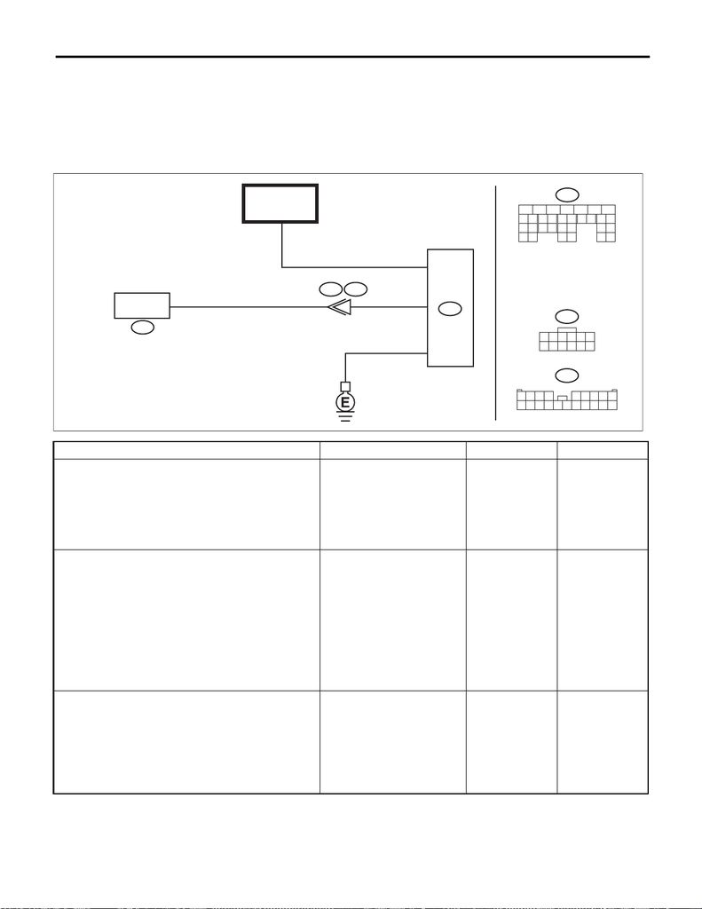

BC(diag)-44

Diagnostic Procedure with Diagnostic Trouble Code (DTC)

BODY CONTROL SYSTEM (DIAGNOSTICS)

2. MODELS WITH KEYLESS ACCESS

DTC DETECTING CONDITION:

UART between the TPMS CM and the body integrated unit is open or shorted, or has communication failure.

TROUBLE SYMPTOM:

TPMS does not operate. (The indicator blinks.)

WIRING DIAGRAM:

Tire Pressure Monitoring System <Ref. to WI-403, WIRING DIAGRAM, Tire Pressure Monitoring System.>

Step Check Yes No

1 CHECK DTC.

1) With the access key in the vehicle, press the

push button ignition switch twice without

depressing the brake to turn the ignition switch

to ON.

2) Read the DTC of body integrated unit using

Subaru Select Monitor.

Is U1500 a current malfunc-

tion?

Go to step 2. Go to step 7.

2 CHECK DTC.

1) Turn the ignition switch to OFF.

2) Disconnect the body integrated unit and the

TPMS CM connector.

3) Connect the disconnected connectors.

4) With the access key in the vehicle, press the

push button ignition switch twice without

depressing the brake to turn the ignition switch

to ON.

5) Read the DTC of body integrated unit using

Subaru Select Monitor.

Is U1500 a current malfunc-

tion?

Go to step 3. Go to step 7.

3 CHECK HARNESS.

1) Turn the ignition switch to OFF.

2) Disconnect the body integrated unit and the

TPMS CM connector.

3) Using the tester, measure the resistance

between terminals.

Connector & terminal

(i171) No. 11 — (R211) No. 11:

Is the resistance 10 Ω or less? Go to step 4. Repair the open

circuit of harness

or replace har-

ness.

11

5

4

i102

1234 56789

10 11 12 13 14 15 16 17 18 19 20

R211

11 12

9

10

78

2

1

i171

19

18

20 21

22

23

26

24

25

27

28 29

30 31

98

15

1413121110

17

16

7123456

D:

D:

i102

R211

R167

i171

D11

LAN01605

TPMS CM

BODY INTEGRATED UNIT

FB-31

F/B FUSE NO. 4

(IG)

[figure not shown]

BC(diag)-45

Diagnostic Procedure with Diagnostic Trouble Code (DTC)

BODY CONTROL SYSTEM (DIAGNOSTICS)

4 CHECK HARNESS.

1) Turn the ignition switch to ON.

2) Use a tester to measure the voltage

between the terminals.

Connector & terminal

(R211) No. 4 (+) — Chassis ground (–):

Is the voltage 10 V or more? Go to step 5. Repair the power

supply circuit.

5 CHECK HARNESS.

Using the tester, measure the resistance

between terminals.

Connector & terminal

(R211) No. 5 — Chassis ground:

Is the resistance 10 Ω or less? Go to step 6. Repair the ground

circuit.

6 CHECK CONTROL MODULE.

1) Turn the ignition switch to OFF.

2) Remove the TPMS CM.

3) Install a TPMS CM that was operating nor-

mally on another vehicle.

Does it operate with the remote

control key of another vehicle?

Replace the TPMS

CM. <Ref. to WT-

10, TPMS CM,

REMOVAL, Tire

Pressure Monitor-

ing System.>

Replace the body

integrated unit.

<Ref. to SL-78,

Body Integrated

Unit.>

7 CHECK CONNECTOR.

Check the connector used for keyless commu-

nication for poor contact.

Is there poor contact of connec-

tor?

Repair the connec-

tor that has poor

contact, or replace

harness.

It is possible that

temporary poor

communication

occurs. Delete the

DTC.

Step Check Yes No